# PLAY Release 1.0: Surveys

## 22. “When told”no”, how often did your child become sadly tearful?”

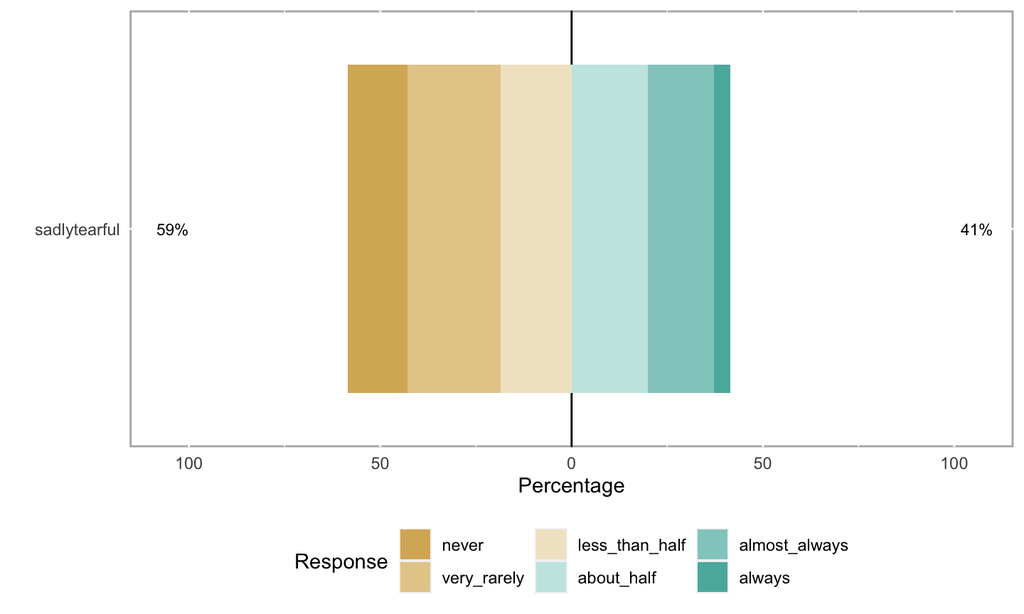

## 23. “Following an exciting activity or event, how often did your child seem to feel down or blue?”

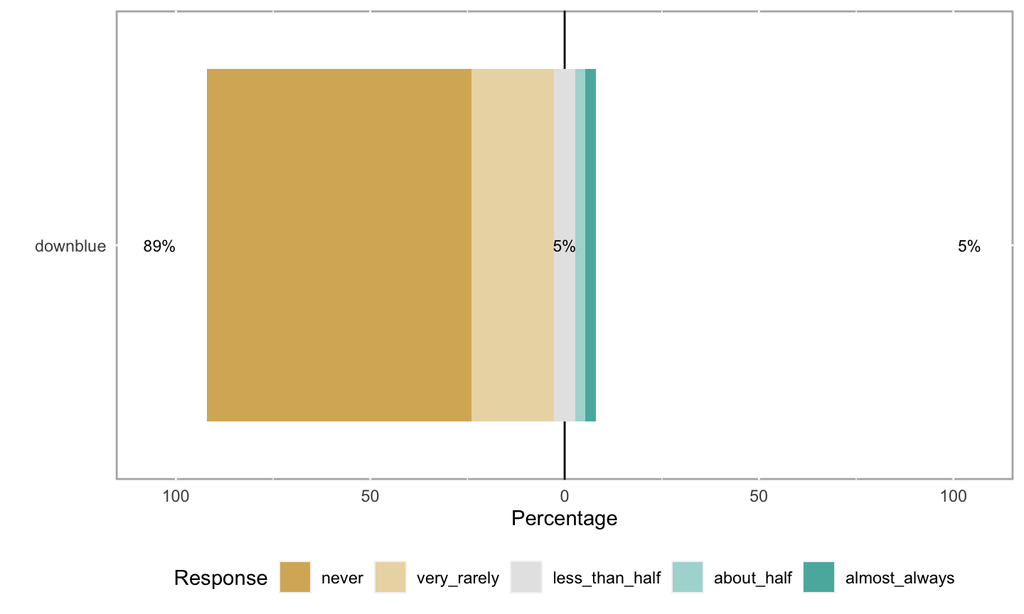

## 24. “When playing indoors, how often did your child run through the house?”

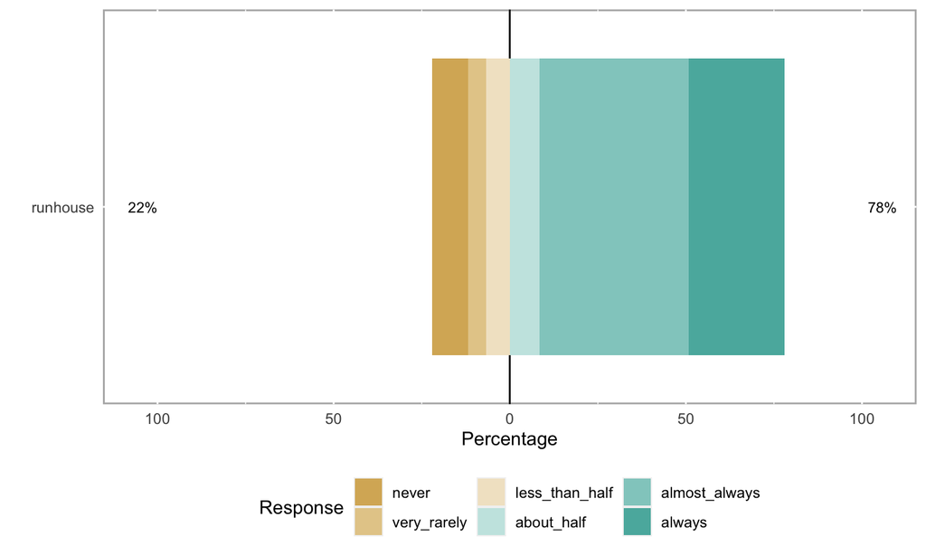

## 25. “Before an exciting event (such as receiving a new toy), how often did your child get very excited about getting it?”

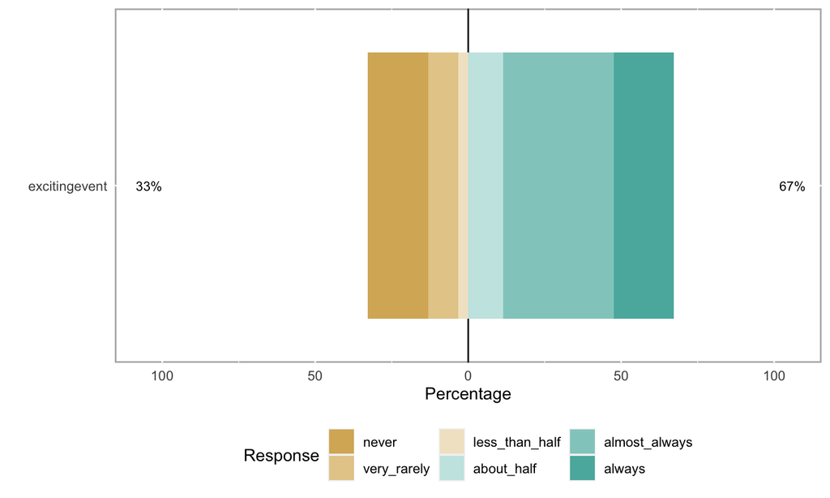

## 26. “When he/she asked for something and you said”no”, how often did your child have a temper tantrum?”

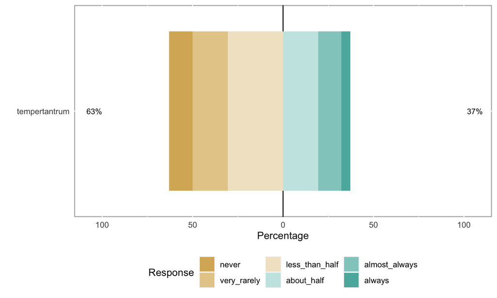

## 27. “When asked to wait for a desirable item (such as ice cream), how often did your child wait patiently?”

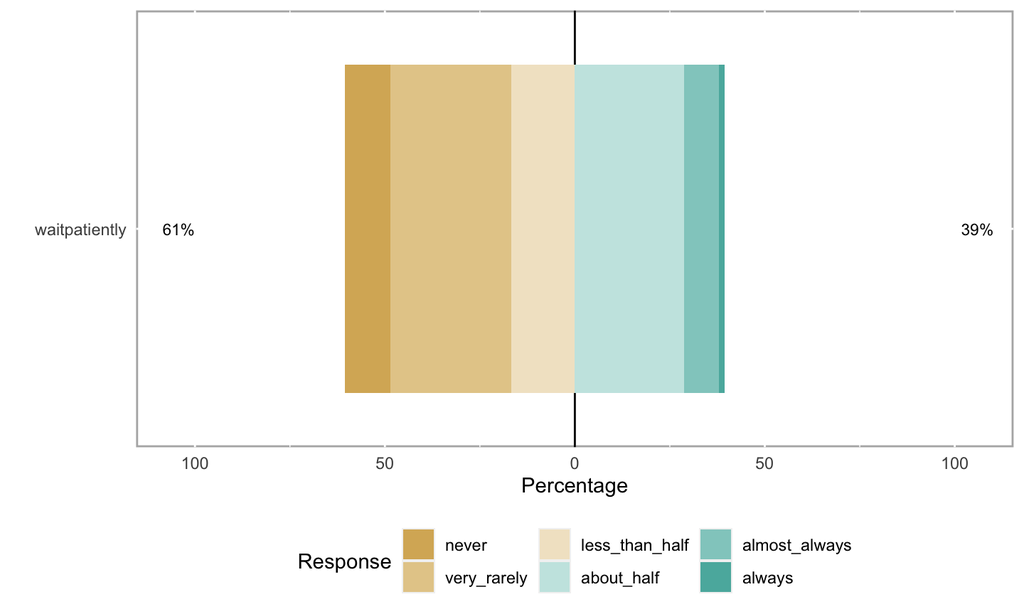

## 28. “When being gently rocked, how often did your child smile?”

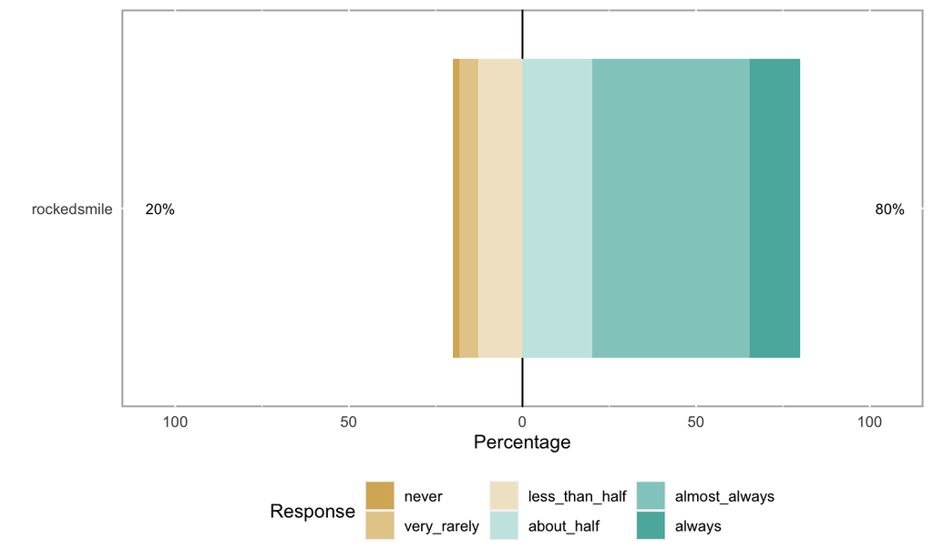

## 29. “While being held on your lap, how often did your child mold to your body?”

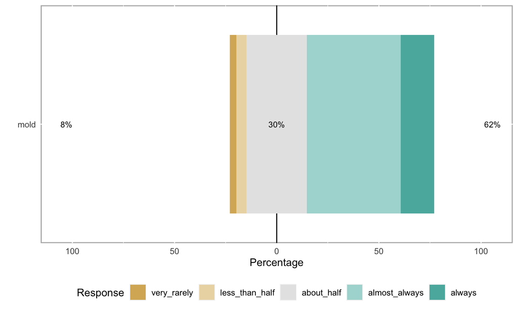

## 30. “When a familiar adult, such as a relative or a friend, visited your home, how often did your child want to interact with the adult?”

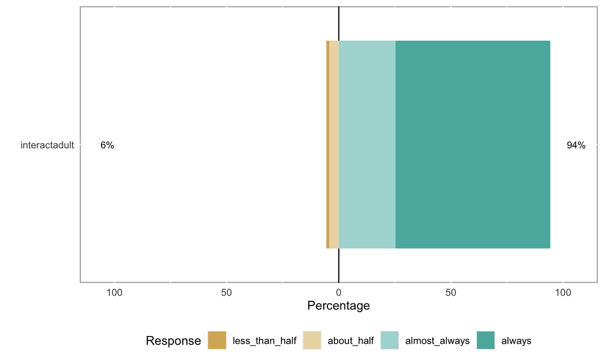

## Clean-up

## Log-out of Databrary

```
## Logout Successful.
```

```
## [1] TRUE
```